# Projet R

Laurène David & Allan Pendant

16/10/2021

### **Question 1 :**

**Proposer un code permettant de regrouper les données contenues dans anime.zip dans un seul et même data.frame.**

```r
#On se place dans le dossier contenant tous les fichiers .csv
setwd("C:/Users/laure/Documents/R_TIDE/anime")

liste <-lapply(list.files(pattern = "*.csv"), function(x) read.csv(x))

df <- do.call("rbind", liste) %>%
      mutate(genre = gsub("Shounen Ai", "shounen Ai", genre)) %>%
      mutate(genre = gsub("Shoujo Ai", "shoujo Ai", genre)) %>% distinct()
```

Aperçu de la table

| anime_id | name | genre | type | episodes | rating | members | rating_10 | rating_100 | rating_1000 |
| --- | --- | --- | --- | --- | --- | --- | --- | --- | --- |
| 32281 | Kimi no Na wa. | Drama, Romance, School, Supernatural | Movie | 1 | 9.37 | 200630 | 9.37 | 127.7577 | 937 |
| 15335 | Gintama Movie: Kanketsu-hen - Yorozuya yo Eien Nare | Action, Comedy, Historical, Parody, Samurai, Sci-Fi, Shounen | Movie | 1 | 9.10 | 72534 | 9.10 | 121.6781 | 910 |
| 28851 | Koe no Katachi | Drama, School, Shounen | Movie | 1 | 9.05 | 102733 | 9.05 | 120.5519 | 905 |
| 199 | Sen to Chihiro no Kamikakushi | Adventure, Drama, Supernatural | Movie | 1 | 8.93 | 466254 | 8.93 | 121.4881 | 893 |
| 12355 | Ookami Kodomo no Ame to Yuki | Fantasy, Slice of Life | Movie | 1 | 8.84 | 226193 | 8.84 | 130.1210 | 884 |

### **Question 2 :**

**Observer pour chaque variable, le nombre et la proportion de valeurs manquantes.**

```r
funs_NA <- function(x){
  list(nombre_NA = sum(is.na(x)), proportion_NA = paste0(round((sum(is.na(x))/ length(x))*100,2),"%"))
}

df_NA <- sapply(df, funs_NA) %>% as.data.frame()
```

Aperçu de df_NA

|  | anime_id | name | genre | type | episodes | rating | members | rating_10 | rating_100 | rating_1000 |
| --- | --- | --- | --- | --- | --- | --- | --- | --- | --- | --- |
| nombre_NA | 0 | 0 | 0 | 0 | 0 | 230 | 0 | 230 | 230 | 230 |
| proportion_NA | 0% | 0% | 0% | 0% | 0% | 1.87% | 0% | 1.87% | 1.87% | 1.87% |

### **Question 3 :**

**Représenter graphiquement la distribution du nombre d’épisodes.**

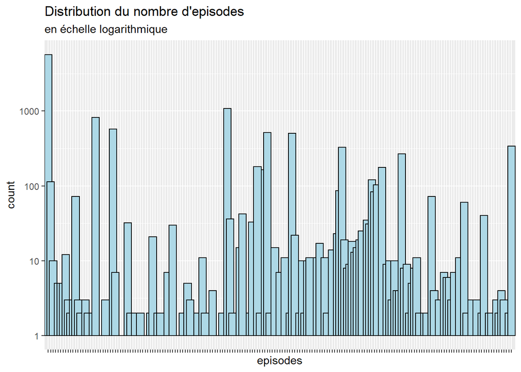

```r
df %>% ggplot(aes(x = episodes)) +
      geom_bar(width=3, color = "black", fill ="lightblue") +
      scale_y_log10() +
      theme(axis.text.x = element_blank()) +
      labs(title="Distribution du nombre d'episodes", subtitle= "en échelle logarithmique")
```

### **Question 4 :**

**Combien d’animes n’ont pas le genre « Shounen » ?**

```r
nb_anime_pas_shounen <- df %>% filter(!grepl("Shounen", genre)) %>% nrow()
```

Le nombre d’anime qui n’ont pas le genre Shounen est de 10583.

### **Question 5 :**

**Donner la proportion de « Shounen » au sein de chaque type d’anime.**

```r
count_type <-df %>% count(type)

prop_<- df %>% mutate(x = ifelse(grepl("Shounen",genre), 1, 0)) %>%
  select(type, genre, x) %>% group_by(type) %>%
  summarise(Shounen = sum(x)) %>%
  mutate(sous_total = count_type[[2]], prop_Shounen = scales::percent(Shounen/sous_total)) %>%
  select(- sous_total) %>% as.data.frame()
```

prop_

| type | Shounen | prop_Shounen |
| --- | --- | --- |
|  | 4 | 16.000% |
| Movie | 375 | 15.971% |
| Music | 0 | 0.000% |
| ONA | 21 | 3.187% |
| OVA | 344 | 10.390% |
| Special | 255 | 15.215% |
| TV | 712 | 18.801% |

### **Question 6 :**

**Créer une fonction permettant de donner la proportion d’un genre quelconque au sein de chaque type d’anime.**

```r
prop_genre <- function(genre_ = "Shounen"){

  count_type <- df %>% count(type)

  df %>% mutate(x = ifelse(grepl(genre_,genre), 1, 0)) %>%
    select(type, genre, x) %>% group_by(type) %>%
    summarise(genre_ = sum(x)) %>%
    mutate(sous_total = count_type[[2]], proportion = scales::percent(genre_/sous_total)) %>%
    as.data.frame()
}
```

Proportions par type du genre: Action

| type | genre_ | sous_total | proportion |
| --- | --- | --- | --- |
|  | 8 | 25 | 32.00% |
| Movie | 572 | 2348 | 24.36% |
| Music | 17 | 488 | 3.48% |
| ONA | 113 | 659 | 17.15% |
| OVA | 680 | 3311 | 20.54% |
| Special | 357 | 1676 | 21.30% |
| TV | 1098 | 3787 | 28.99% |

### **Question 7 :**

**Proposer une représentation graphique permettant d’observer au sein de chaque type d’anime, quels genres sont les plus représentés.**

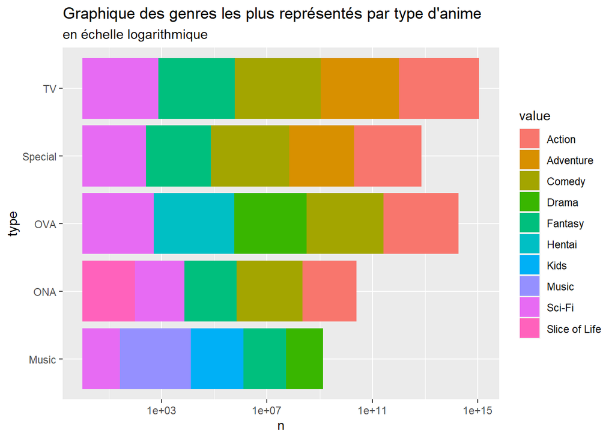

```r
list_type <- c("Music", "ONA", "OVA", "Special", "TV")


df_q8 <- function(type_) {df %>%
    separate(genre, into = letters[1:13] ,sep=", ", fill = "right") %>%
    select(a:m, type) %>%
    filter(type == type_) %>%
    select(-type) %>%
    gather() %>%
    count(value) %>%
    mutate(type = type_) %>%
    arrange(desc(n)) %>%
    slice(2:6)
}

df_lapply <- lapply(list_type, function(x) df_q8(x))

df_top_genre <- do.call("rbind", df_lapply)

df_top_genre %>%
  ggplot(aes(x = type, y=n)) + geom_col(aes(fill=value)) + scale_y_log10() + labs(title="Graphique des genres les plus représentés par type d'anime", subtitle= "en échelle logarithmique") + coord_flip()
```

### **Question 8 :**

**Pour toutes les variables de types « rating ». Calculer la moyenne, la médiane, l’écart type, la mad (median absolute deviation), le coefficient de variation, la valeur maximum et la valeur minimum. Représentez graphiquement ces résultats.**

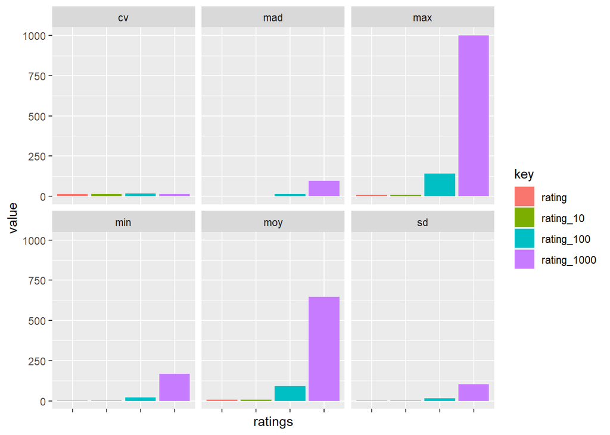

```r
stats_ <- function(x){
  list(moy = mean(x), sd = sd(x), mad = mad(x), cv = sd(x)/mean(x)*100,
       max = max(x), min = min(x))
}

stats_names <- df %>%
  select(starts_with("rating")) %>%
  drop_na() %>%
  sapply(stats_) %>% rownames()

df_stats <- df %>%
        select(starts_with("rating")) %>%
        drop_na() %>%
        sapply(stats_) %>%
        as.data.frame() %>% gather() %>% mutate(funs = rep(c("moy","sd","mad","cv","max","min"),4))


df_stats %>% ggplot(aes(x = key, y = value, fill= key)) + geom_col() + facet_wrap("funs") + theme(axis.text.x = element_blank()) + labs(x = "ratings")
```

### **Question 9 :**

**Proposer une représentation graphique permettant d’observer s’il existe une différence de notation en fonction du genre d’anime.**

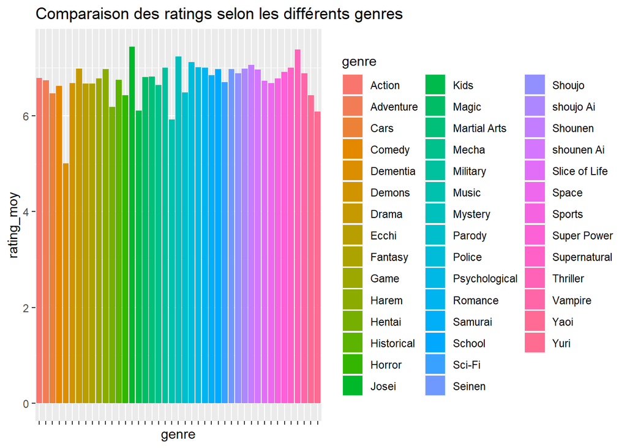

```r
genre_list <- df %>%
    separate(genre, into = letters[1:13] ,sep=", ", fill = "right") %>%
    select(a:m) %>%
    gather() %>%
    drop_na() %>%
    count(value) %>%
    select(value) %>%
    slice(2:length(value)) %>%
    as.list()


genre_rating <- function(genre_) {
  df %>%
    filter(grepl(genre_,genre)) %>%
    select(rating) %>%
    drop_na() %>%
    summarise(rating_moy = mean(rating)) %>%
    mutate(genre = genre_)
}

genre_list_df <- lapply(genre_list[[1]], function(x) genre_rating(x))

df_q9 <- do.call("rbind", genre_list_df) %>%
          arrange(desc(rating_moy)) %>%
          mutate(rating_moy = round(rating_moy,2))

df_q9 %>% ggplot(aes(x=genre, y=rating_moy, fill=genre)) + geom_col() + theme(axis.text.x = element_blank()) + labs(title="Comparaison des ratings selon les différents genres")
```

### **Question 10 :**

**Pour chaque genre d’anime, représenter graphiquement le top 10 des animes les mieux notés.**

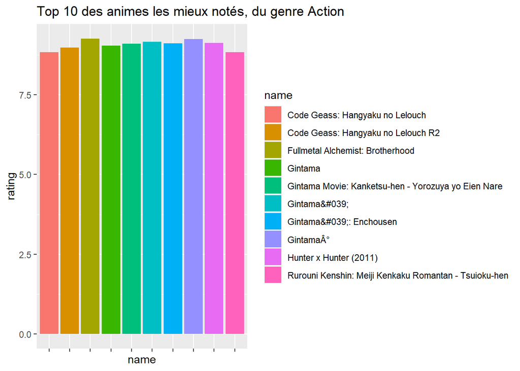

```r
#Fonction pour construire dataframe avec le top 10 des animes, en fonction du genre
df_top10anime <- function(genre_) {
  df %>%
    filter(grepl(genre_,genre)) %>%
    select(rating, name) %>%
    mutate(genre = genre_) %>%
    arrange(desc(rating)) %>%
    head(10)
  }



#Concaténation des dataframes avec chaque genre:
genre_list_df <- lapply(genre_list[[1]], function(x) df_top10anime(x))
df_q10 <- do.call("rbind", genre_list_df)

## utilisation d'un "facet_wrap("genre")" avec mon ggplot() ne fonctionne pas
## La variable "genre" a trop de modalités


#Graphique pour quelques genres
df_top10anime("Action") %>% ggplot(aes(x=name, y=rating, fill = name)) + geom_col() + theme(axis.text.x = element_blank()) + labs(title = "Top 10 des animes les mieux notés, du genre Action")
```

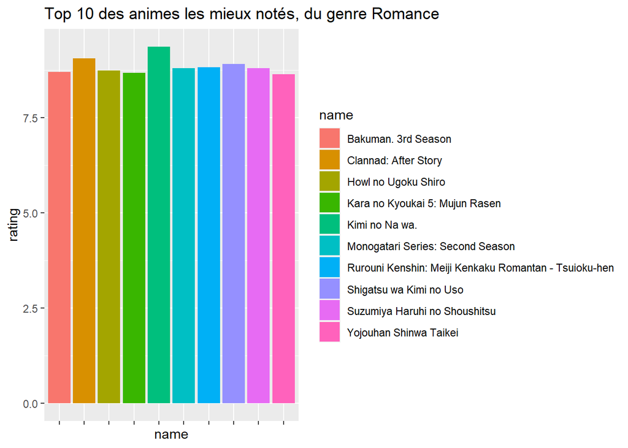

```r
df_top10anime("Romance") %>% ggplot(aes(x=name, y=rating, fill = name)) + geom_col() + theme(axis.text.x = element_blank()) + labs(title = "Top 10 des animes les mieux notés, du genre Romance")
```

### **Question 11 :**

**Etablir une critique sur les données et les statistiques que vous avez produites. Proposer éventuellement d’autres analyses pour compléter.**

**Critique sur les données :**

- On remarque que les colonnes «rating» et «rating_10» sont identiques, il n’est pas necessaire de garder les deux variables pour nos analyses.
- Certaines valeurs de la variable «rating_100» sont supérieurs à 100, ce qui ne semble pas adéquat pour des notes sur 100 et ce qui fausse les statistiques calculées à la question 8.
- Les graphiques proposés à la question 8 ne sont pas pertinents puisqu’on compare des notes qui n’ont pas toutes la même échelle .

Pour la **question 3**, les modalités de la variable “episodes” sont trop nombreuses, ce qui pose problème lorsqu’on cherche à représenter la distribution du nombre d’épisodes. Nous proposons de regrouper ces modalités en différentes classes (intervalles) pour rendre le graphique plus lisible et les informations présentées plus pertinentes.

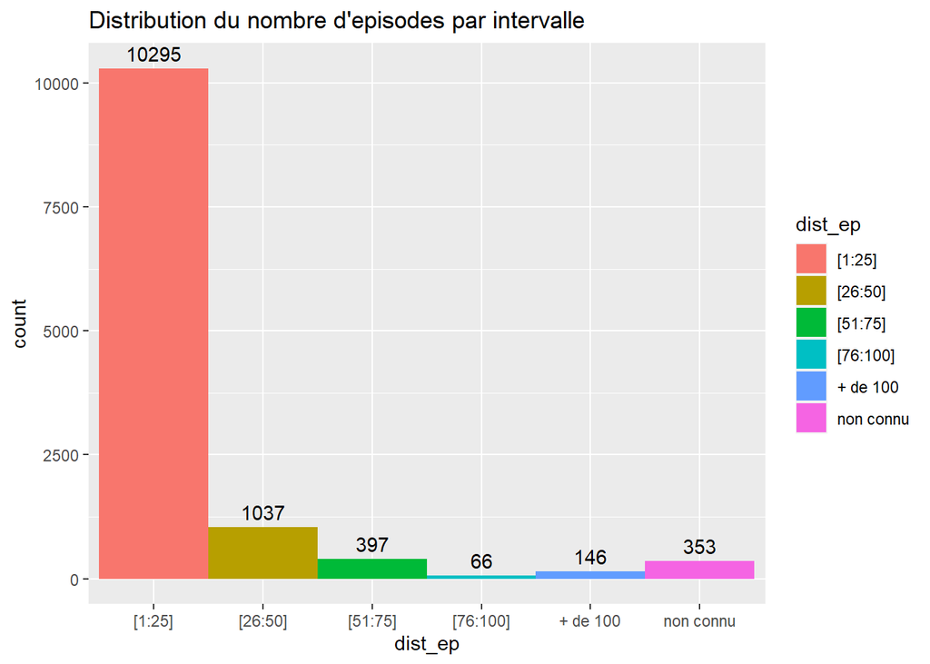

```r
#Création des intervalles :
new_df <- df %>% mutate(dist_ep = ifelse(episodes %in% (1:25), "[1:25]",
                                         ifelse (episodes %in% (26:50), "[26:50]",
                                                 ifelse(episodes %in% (51:75), "[51:75]",
                                                        ifelse(episodes %in% (76:100), "[76:100]",
                                                               ifelse(episodes %in% (100:500), "+ de 100","non connu"))))))


#Creation du graphique :
new_df %>% ggplot(aes(x = dist_ep, fill = dist_ep)) +
  geom_bar(width=1) +
  #scale_y_log10() +
  labs(title="Distribution du nombre d'episodes par intervalle") +
  geom_text(aes(label=after_stat(count)), stat = "count", position=position_dodge(width=0.9), vjust=-0.5)
```

Pour la **question 8**, nous avons reproduit les mêmes graphiques en modifiant les variables “rating_100” et “rating_1000” pour les ramener à une note sur 10, en supprimant la variable “rating” et en ramenant les notes superieur à 100 à la valeur 100.

```r
df_stats_new <- df %>%
              select(starts_with("rating")) %>%
              drop_na() %>%
              mutate(rating_100 = (ifelse(rating_100 >100,100,rating_100))/10, rating_1000 = rating_1000/100) %>%  select(-rating) %>%  sapply(stats_) %>% as.data.frame() %>% gather()  %>% mutate(funs = rep(c("moy","sd","mad","cv","max","min"),3))
```

Aperçu de la table

| key | value | funs |
| --- | --- | --- |
| rating_10 | 6.473902 | moy |
| rating_10 | 1.026746 | sd |
| rating_10 | 0.96369 | mad |
| rating_10 | 15.85978 | cv |
| rating_10 | 10 | max |
| rating_10 | 1.67 | min |
| rating_100 | 8.865714 | moy |
| rating_100 | 1.222975 | sd |
| rating_100 | 1.208029 | mad |
| rating_100 | 13.79443 | cv |
| rating_100 | 10 | max |
| rating_100 | 2.226028 | min |
| rating_1000 | 6.473902 | moy |
| rating_1000 | 1.026746 | sd |
| rating_1000 | 0.96369 | mad |
| rating_1000 | 15.85978 | cv |
| rating_1000 | 10 | max |
| rating_1000 | 1.67 | min |

Voici la nouvelle représentation graphique des différentes statistiques des variables “rating”.

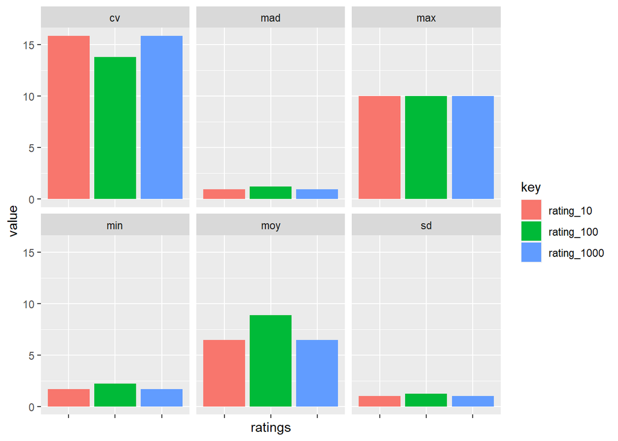

```r
df_stats_new %>% ggplot(aes(x = key, y = value, fill= key)) + geom_col() + facet_wrap("funs") + theme(axis.text.x = element_blank()) + labs(x = "ratings")
```

Pour la **question 9**, la variable “genre” dispose de trop de modalités, ce qui rend le graphique difficile à lire. Nous proposons de simplement sélectionner les 8 genres les mieux notés, ainsi que les 8 genres les moins bien notés.*

Voici le graphique des 8 genres les mieux notés :

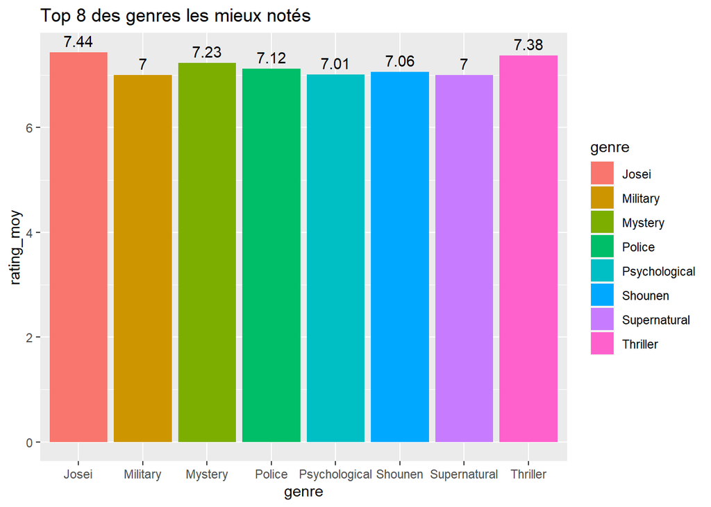

```r
df_q9 %>% head(8) %>%  ggplot(aes(x=genre, y=rating_moy, fill=genre)) + geom_col()+labs(title= "Top 8 des genres les mieux notés") + geom_text(aes(label=rating_moy), position=position_dodge(width=0.9), vjust=-0.5)
```

Voici le graphique des 8 genres les moins bien notés :

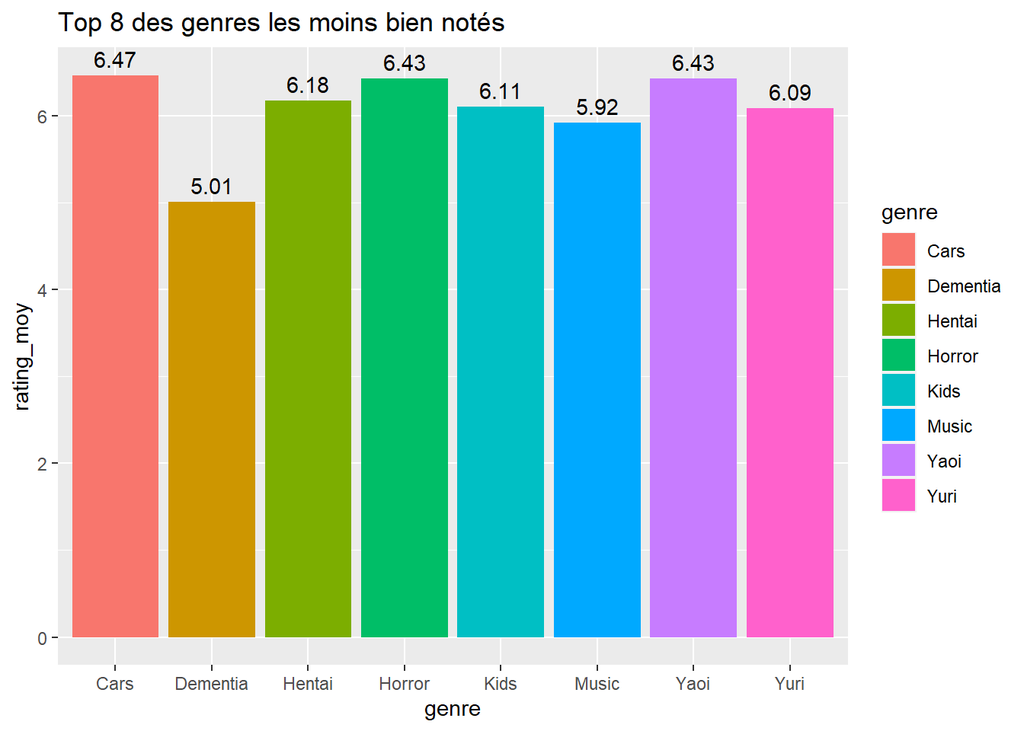

```r
df_q9 %>% tail(8) %>%  ggplot(aes(x=genre, y=rating_moy, fill=genre)) + geom_col()+labs(title= "Top 8 des genres les moins bien notés") + geom_text(aes(label=rating_moy), position=position_dodge(width=0.9), vjust=-0.5)
```